# TP2

Elliott Perryman, Jan Zavadil, Ignat Sabaev

1/3/2022

## 1 Data

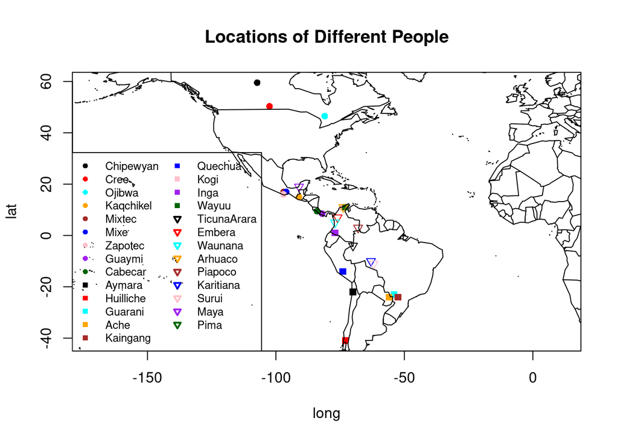

## 2 Regression

```
##
## Call:
## lm(formula = long ~ ., data = NAaux)
##
## Residuals:
## ALL 494 residuals are 0: no residual degrees of freedom!
##
## Coefficients: (5216 not defined because of singularities)
##                         Estimate Std. Error t value Pr(>|t|)
## (Intercept)            1250.3745         NA      NA       NA
## L1.125                 -171.2557         NA      NA       NA
## L1.130                   44.7543         NA      NA       NA
## L1.135                  -54.5783         NA      NA       NA
## L1.140                 -264.3330         NA      NA       NA
## L1.142                 -792.4778         NA      NA       NA
## L1.145                   65.6649         NA      NA       NA
## L1.150                   51.0931         NA      NA       NA
## L1.150.940397350993      25.7019         NA      NA       NA
## L1.152                 -249.8699         NA      NA       NA
## L1.155                   25.2062         NA      NA       NA
## L1.160                   67.5255         NA      NA       NA
##  [ reached getOption("max.print") -- omitted 5698 rows ]
##
## Residual standard error: NaN on 0 degrees of freedom
## Multiple R-squared:      1,  Adjusted R-squared:    NaN
## F-statistic:   NaN on 493 and 0 DF,  p-value: NA
```

The linear model does not return valid results since the number of observations is lower than the number of predictors.

## 3 PCA

#### a)

Principle Component Analysis is a statistical method used to lower dimension of observed data. It aims to represent the data in low dimensions while keeping as much variance (and therefore information) in the data as possible.

#### b)

In this case the scaling option of *prcomp* function should not be used. All the variable are of value 0 or 1, therefore any difference in variance between them is a valuable information which would be lost by scaling the data.

#### c)

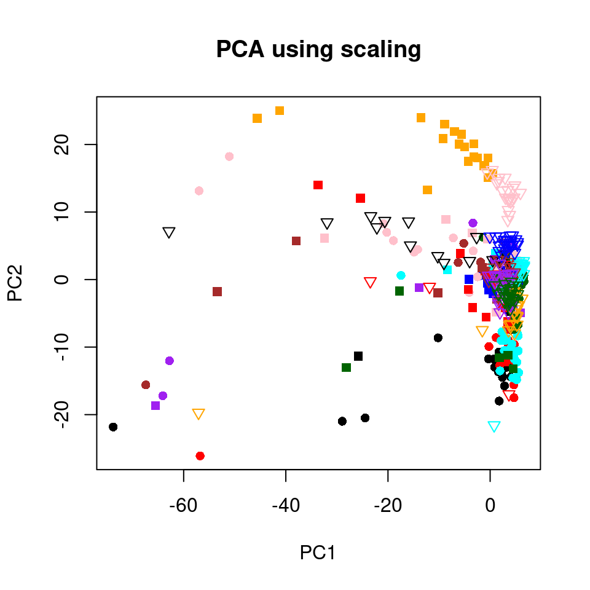

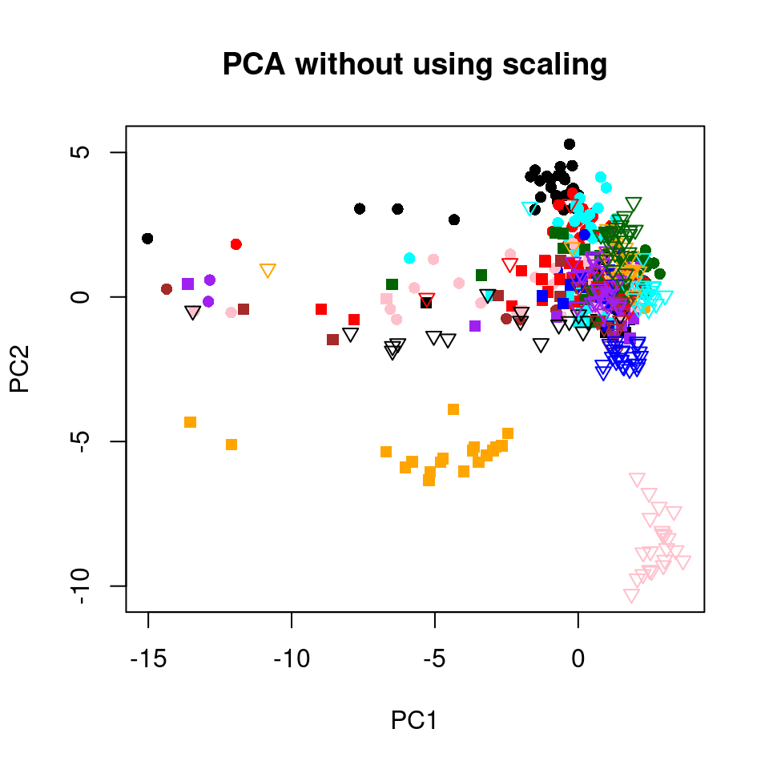

From these figures, we can say that, while there are some populations with distinguishable genetical markers (Ache, Surui), the majority of individuals create a big shared cluster and therefore it will be quite difficult to distinguish between certain populations.

#### d)

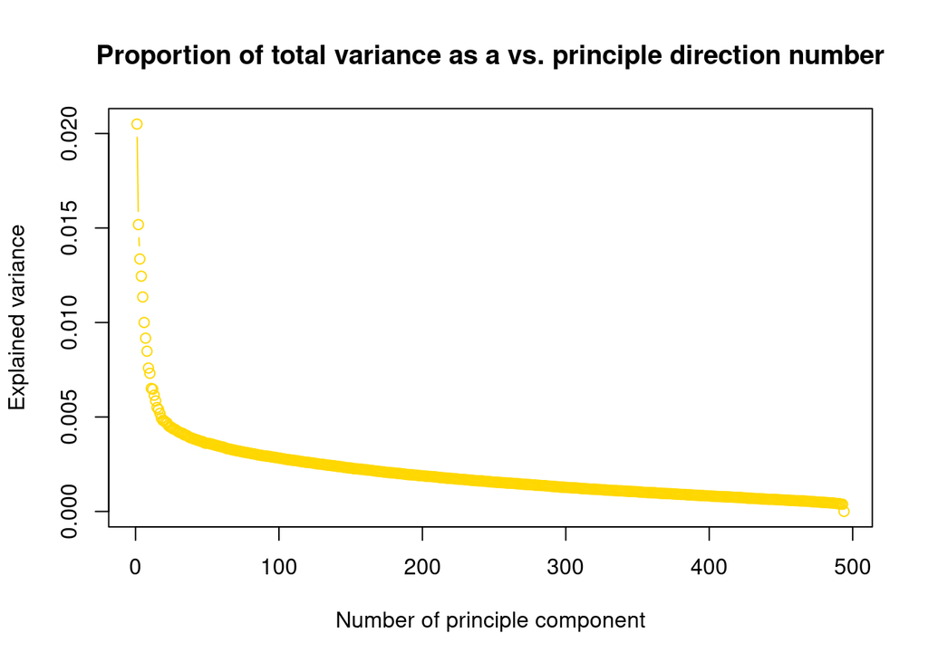

## 4 PCR (Principal components regression)

#### a)

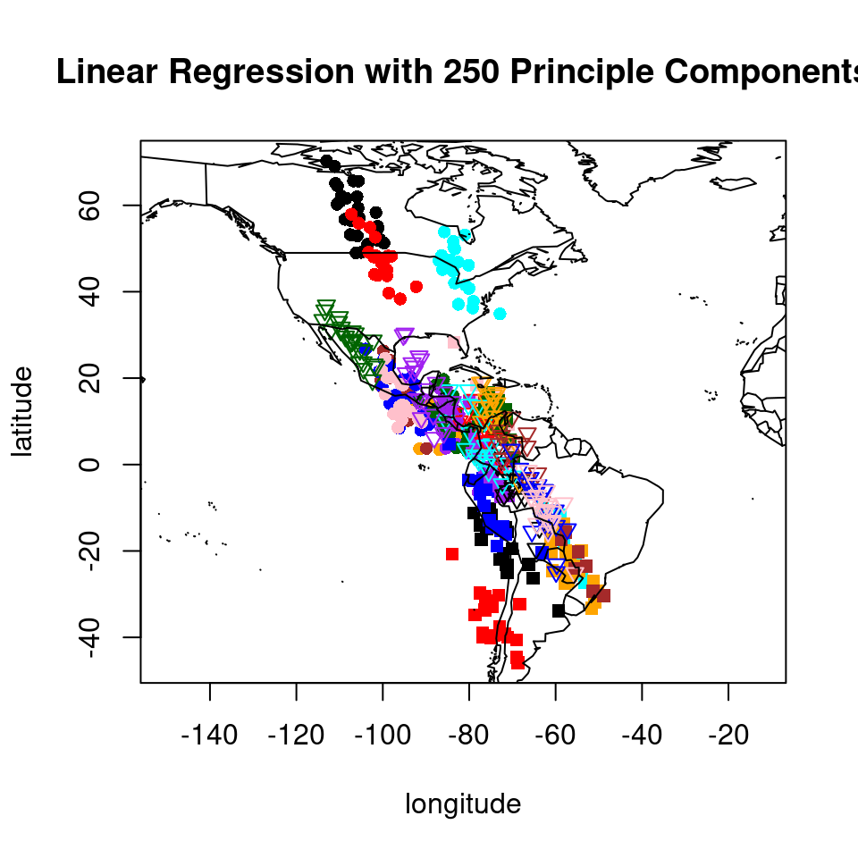

If we compare this plot with the previous map we can see that the estimated locations of individuals of a certain population create a cluster of points which is usually centered around the original location of this population. This gives us certain hope to be able to find very approximate geographical origin of an unknown individual.

#### b)

```r
metric(lmlong, lmlat)
```

```
##          [,1]
## [1,] 1177.612
```

The mean error of previous model is ~1,200 km.

## 5 PCR and cross-validation

### (a)

Cross validation is a method for comparing models. This is designed to help against the problem of overfitting. This divides the dataset into random samples, trains smaller models on the random subsets, and compares generalization power against unseen examples. Then the final model is trained on the entire dataset. For the PCR case, the model size is the number of principle components to include. This methodology uses 10 fold cross validation. THe results are shown below.

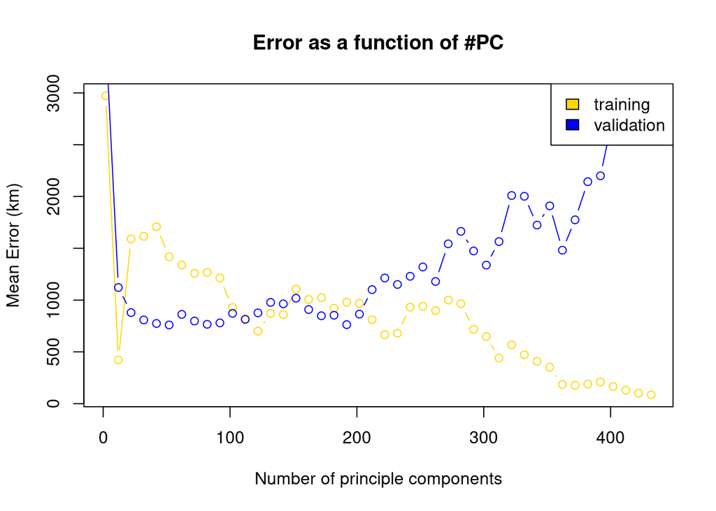

Looking at the training and mean validation error, it seems that the model with 52 principle components is best. This model has the lowest validation error and seems to have fairly low number of principle components. The output of this model is shown below.

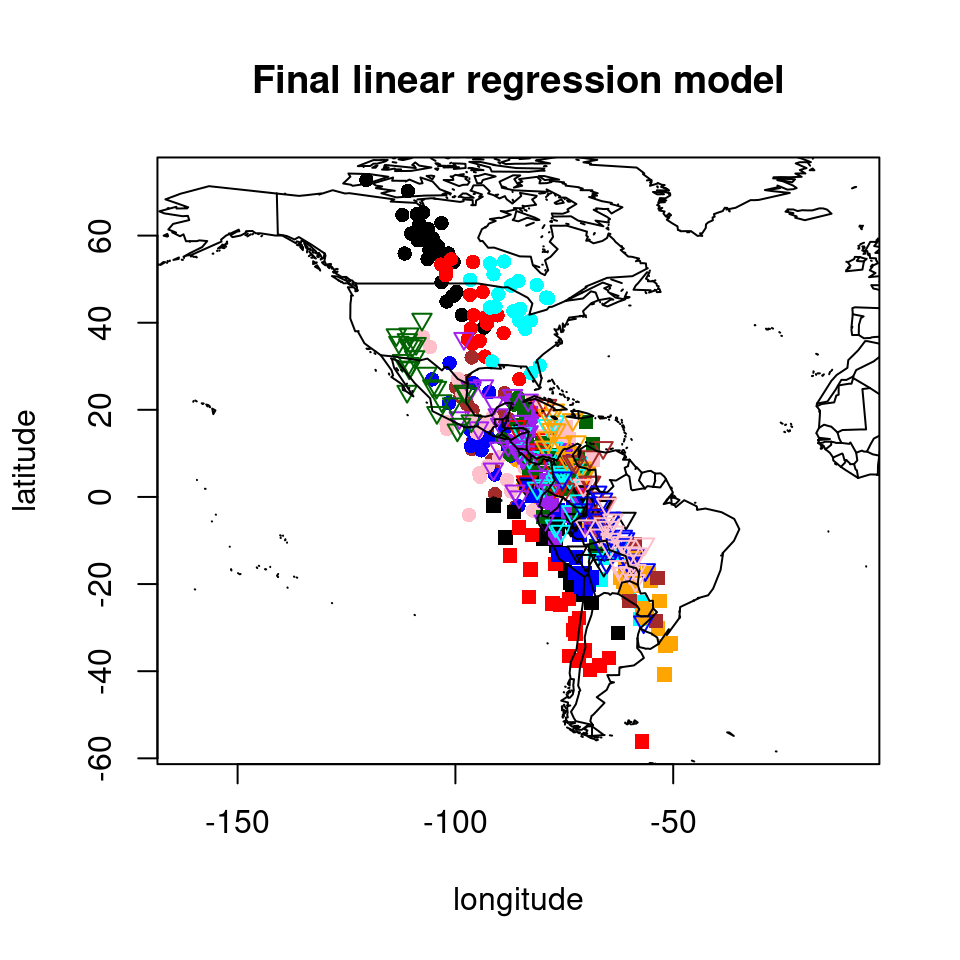

The mininum validation error is ~800 km for this model.

```r
min(validation_error)
```

```
## [1] 759.9712
```

## 6

In conclusion, we used cross validation to choose the number of dimensions to use in PCR (52), and implemented PCR with these 52 dimensions. The final average prediction error is about 800 km. The final model thus gives us a possibility to roughly estimate the origin of a new individual based on his genetical markers. This model could be improved by increasing the number of training data.